# 녹조예측 뉴스레터

sung won kang

2023 9 7

### Section 2. 녹조예측

#### A. Data

분석 대상 Data는 2023년 “환경 빅데이터 분석 및 서비스 개발” 과제에서 구축한 녹조 예측 CNN 모형의 Chlorophyll-a 예측치이다. 이 모형은 2016년부터 2022년까지의 수질오염도 자료를 이용하여 1주 이후의 Chlorophyll-a 농도를 예측한다. 예측의 대상은 안정적으로 물환경정보시스템의 API 계정을 통해 데이터를 확보할 수 있는 16 수질오염자동측정소이다.

- 예측 대상 측정소 : 안동1, 안동4, 반변천4, 금호강8, 곡교천2, 고령, 구포, 학성, 적성, 물금, 내성천5, 남강7, 남지, 논산천4, 상주3, 산곡

#### B. 예측결과

각 측정소에서 예측 가능한 최근 시점에 Chlorophyll-a 예측치가 25$\mu g/m^3$ 이상이어서 녹조 농도가 높을 것으로 예측되는 측정소는 아래의 표에 수록한 7개 측정소이다. 아래 표의 각각의 행에 수록된 변수의 정의는 다음과 같다.

- 측정소 : 예측의 대상인 측정소
- 예측시점 : 예측 가능한 최근 시점
- 예측치 : 예측시점의 Chlorophyll-a 예측치

| 측정소 | 예측치 | 예측시점 |
| --- | --- | --- |
| 곡교천2 | 71.69 | 2023-7-1 |
| 논산천4 | 40.40 | 2023-7-1 |
| 금호강8 | 39.53 | 2023-7-1 |
| 구포 | 26.70 | 2023-7-1 |
| 학성 | 26.07 | 2023-7-1 |
| 남강7 | 25.37 | 2023-7-1 |
| 남지 | 25.32 | 2023-7-1 |

위의 표에 수록된 측정소의 위치를 지도에 표시하면 다음과 같다. 점의 크기가 클 수록 예상 녹조 농도가 높은 측정소이다.

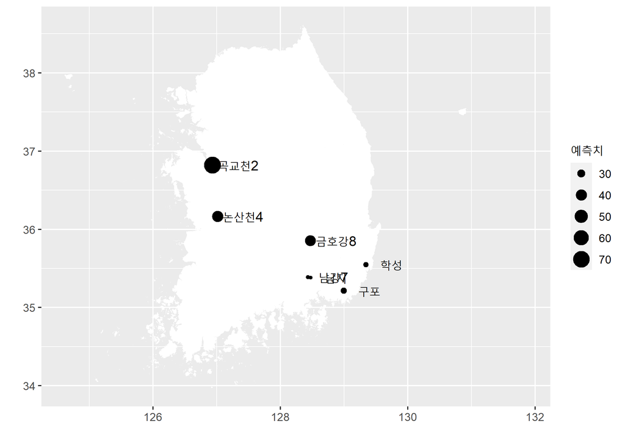

**녹조 위험 예고 지역**